# Machine learning course project

Yanshan Jin

2024-07-07

## R Markdown

Background

Using devices such as Jawbone Up, Nike FuelBand, and Fitbit it is now possible to collect a large amount of data about personal activity relatively inexpensively. These type of devices are part of the quantified self movement – a group of enthusiasts who take measurements about themselves regularly to improve their health, to find patterns in their behavior, or because they are tech geeks. One thing that people regularly do is quantify how much of a particular activity they do, but they rarely quantify how well they do it. In this project, your goal will be to use data from accelerometers on the belt, forearm, arm, and dumbell of 6 participants. They were asked to perform barbell lifts correctly and incorrectly in 5 different ways. More information is available from the website here: http://web.archive.org/web/20161224072740/http:/groupware.les.inf.puc-rio.br/har (see the section on the Weight Lifting Exercise Dataset).

Data

The training data for this project are available here:

https://d396qusza40orc.cloudfront.net/predmachlearn/pml-training.csv

The test data are available here:

https://d396qusza40orc.cloudfront.net/predmachlearn/pml-testing.csv

The data for this project come from this source: http://web.archive.org/web/20161224072740/http:/groupware.les.inf.puc-rio.br/har . If you use the document you create for this class for any purpose please cite them as they have been very generous in allowing their data to be used for this kind of assignment.

```r
setwd(dirname(rstudioapi::getActiveDocumentContext()$path))
```

```r
library(lattice)
library(ggplot2)
library(caret)
library(rpart)
library(rpart.plot)
library(corrplot)
library(rattle)
library(randomForest)
library(RColorBrewer)

set.seed(222)
```

## Load data for analysis.

```r
url_train <- "https://d396qusza40orc.cloudfront.net/predmachlearn/pml-training.csv"
url_test <- "https://d396qusza40orc.cloudfront.net/predmachlearn/pml-testing.csv"

data_train <- read.csv(url(url_train), strip.white = TRUE, na.strings = c("NA",""))
data_test <- read.csv(url(url_test),strip.white = TRUE, na.strings = c("NA",""))

dim(data_train)
```

```
## [1] 19622   160
```

```r
dim(data_test)
```

```
## [1]  20 160
```

## Create two portions within the original training set.

```r
in_train <- createDataPartition(data_train$classe, p = 0.75, list = FALSE)
train_set <- data_train[in_train,]
test_set <- data_train[-in_train,]

dim(train_set)
```

```
## [1] 14718   160
```

```r
dim(test_set)
```

```
## [1] 4904  160
```

```r
# organizing training set and test set -
# removing near-zero-varience variables.
nzv <- nearZeroVar(train_set)
train_set <- train_set [,-nzv]
test_set <- test_set[,-nzv]
dim(train_set)
```

```
## [1] 14718   120
```

```r
# removing NAs
na_var <- sapply(train_set, function(x) mean(is.na(x))) > 0.95
train_set <- train_set[,na_var==FALSE]
test_set <- test_set[,na_var==FALSE]

dim(train_set)
```

```
## [1] 14718    59
```

```r
dim(test_set)
```

```
## [1] 4904   59
```

```r
# remove the identification variables.

train_set <-  train_set[,-(1:5)]
test_set <- test_set[,-(1:5)]

dim(train_set)
```

```
## [1] 14718    54
```

```r
# transforming the vairbale that need to be predicted to a factor variable, when it is a integer.
train_set$classe <- factor(train_set$classe)
test_set$classe <- factor(test_set$classe)
```

the number of variables has been reduced from original 160 to 54.

## Correlation analysis

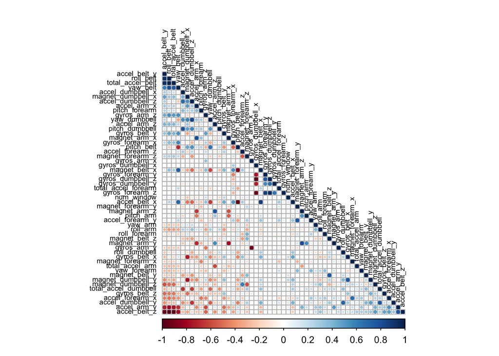

```r
# Correlation analysis is performed to see the correlation of the variables. if they are highly correlated, then we need to perform PCA analysis to reduce data demension. If not, we go ahead and use the original data.

corr_matrix <- cor(train_set[,-54])
corrplot(corr_matrix, order = "FPC", method = "circle", type = "lower",
         tl.cex = 0.6, tl.col = rgb(0,0,0))
```

```r
# since not many variables are highly correlated, we will not perform PCA analysis.
```

```r
set.seed(2222)
train_control <- trainControl(method = "cv", number = 5) # 5-fold cross validation
# train the decision tree model using 5-fold cross validation
fit_decision_tree_cv <- train(classe ~.,data = train_set, method = "rpart",
                              trControl = train_control)
# print the results
print(fit_decision_tree_cv)
```

```
## CART
##
## 14718 samples
##    53 predictor
##     5 classes: 'A', 'B', 'C', 'D', 'E'
##
## No pre-processing
## Resampling: Cross-Validated (5 fold)
## Summary of sample sizes: 11773, 11775, 11774, 11775, 11775
## Resampling results across tuning parameters:
##
##   cp          Accuracy   Kappa
##   0.03792842  0.5508883  0.42431523
##   0.05599070  0.4544173  0.26851646
##   0.11535175  0.3333948  0.07507222
##
## Accuracy was used to select the optimal model using the largest value.
## The final value used for the model was cp = 0.03792842.
```

[figure not shown]

```r
# plot the decision tree
fancyRpartPlot(fit_decision_tree_cv$finalModel)
```

Prediction on the test_set.

```r
predict_decision_tree <- predict(fit_decision_tree_cv, newdata = test_set,type = "raw")
conf_matrix_decision_tree <- confusionMatrix(predict_decision_tree,test_set$classe)
conf_matrix_decision_tree
```

```
## Confusion Matrix and Statistics
##
##           Reference
## Prediction    A    B    C    D    E
##          A 1231  393  406  342   88
##          B   20  329   26  146   65
##          C  119  227  423  281  179
##          D    0    0    0    0    0
##          E   25    0    0   35  569
##
## Overall Statistics
##
##                Accuracy : 0.5204
##                  95% CI : (0.5063, 0.5345)
##     No Information Rate : 0.2845
##     P-Value [Acc > NIR] : < 2.2e-16
##
##                   Kappa : 0.3746
##
##  Mcnemar's Test P-Value : < 2.2e-16
##
## Statistics by Class:
##
##                      Class: A Class: B Class: C Class: D Class: E
## Sensitivity            0.8824  0.34668  0.49474   0.0000   0.6315
## Specificity            0.6498  0.93502  0.80094   1.0000   0.9850
## Pos Pred Value         0.5004  0.56143  0.34418      NaN   0.9046
## Neg Pred Value         0.9329  0.85642  0.88245   0.8361   0.9223
## Prevalence             0.2845  0.19352  0.17435   0.1639   0.1837
## Detection Rate         0.2510  0.06709  0.08626   0.0000   0.1160
## Detection Prevalence   0.5016  0.11949  0.25061   0.0000   0.1283
## Balanced Accuracy      0.7661  0.64085  0.64784   0.5000   0.8083
```

plot the accuracy of the decision tree model.

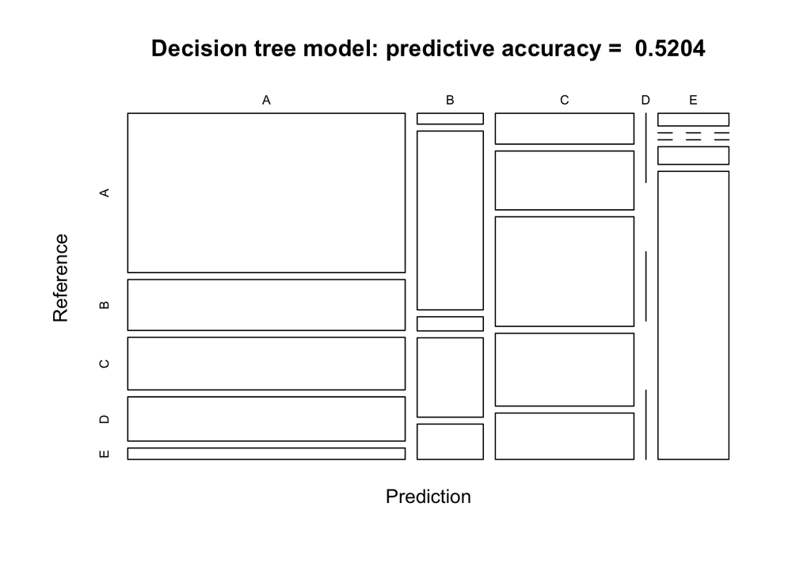

```r
plot(conf_matrix_decision_tree$table,col = conf_matrix_decision_tree$byClass,
     main = paste("Decision tree model: predictive accuracy = ", round(conf_matrix_decision_tree$overall['Accuracy'],4)))
```

Apply random forest model on the train_set.

```r
set.seed(2222)
train_control <- trainControl(method = "cv", number = 5) # 5-fold cross validation
# train the decision tree model using 5-fold cross validation
fit_RF <- train(classe ~.,data = train_set, method = "rf",
                              trControl = train_control)
# print the model
fit_RF$finalModel
```

```
##
## Call:
##  randomForest(x = x, y = y, mtry = param$mtry)
##                Type of random forest: classification
##                      Number of trees: 500
## No. of variables tried at each split: 27
##
##         OOB estimate of  error rate: 0.23%
## Confusion matrix:
##      A    B    C    D    E  class.error
## A 4182    2    0    0    1 0.0007168459
## B    5 2840    2    1    0 0.0028089888
## C    0    5 2562    0    0 0.0019477990
## D    0    0    8 2403    1 0.0037313433
## E    0    1    0    8 2697 0.0033259424
```

```r
predict_RF <- predict(fit_RF,newdata = test_set)
conf_matrix_RF <- confusionMatrix(predict_RF, test_set$classe)
conf_matrix_RF
```

```
## Confusion Matrix and Statistics
##
##           Reference
## Prediction    A    B    C    D    E
##          A 1395    4    0    0    0
##          B    0  945    2    0    0
##          C    0    0  853    6    0
##          D    0    0    0  798    1
##          E    0    0    0    0  900
##
## Overall Statistics
##
##                Accuracy : 0.9973
##                  95% CI : (0.9955, 0.9986)
##     No Information Rate : 0.2845
##     P-Value [Acc > NIR] : < 2.2e-16
##
##                   Kappa : 0.9966
##
##  Mcnemar's Test P-Value : NA
##
## Statistics by Class:
##
##                      Class: A Class: B Class: C Class: D Class: E
## Sensitivity            1.0000   0.9958   0.9977   0.9925   0.9989
## Specificity            0.9989   0.9995   0.9985   0.9998   1.0000
## Pos Pred Value         0.9971   0.9979   0.9930   0.9987   1.0000
## Neg Pred Value         1.0000   0.9990   0.9995   0.9985   0.9998
## Prevalence             0.2845   0.1935   0.1743   0.1639   0.1837
## Detection Rate         0.2845   0.1927   0.1739   0.1627   0.1835
## Detection Prevalence   0.2853   0.1931   0.1752   0.1629   0.1835
## Balanced Accuracy      0.9994   0.9976   0.9981   0.9961   0.9994
```

visualize the results of random forest prediction.However, the accuracy is too high and all curves overlaped together.

```r
library(pROC)
```

```r
# predict proabilities
pred_prob <- predict(fit_RF, newdata = test_set, type = "prob")
# create actural classes
actual_classes <- test_set$classe
# generate ROC curves for each classes
roc_list <- lapply(levels(actual_classes), function(class){
        roc(response = as.numeric(actual_classes == class),
            predictor = pred_prob[,class],
            levels = c(0,1),
            direction = "<"
            )
})
# plot ROC curves
plot(roc_list[[1]],col = 1, main = "ROC curves for each class", print.auc = TRUE)
sapply(2:length(roc_list),function(i) {
        plot(roc_list[[i]], col = i, add = TRUE, print.auc = TRUE)
})
```

[output not shown]

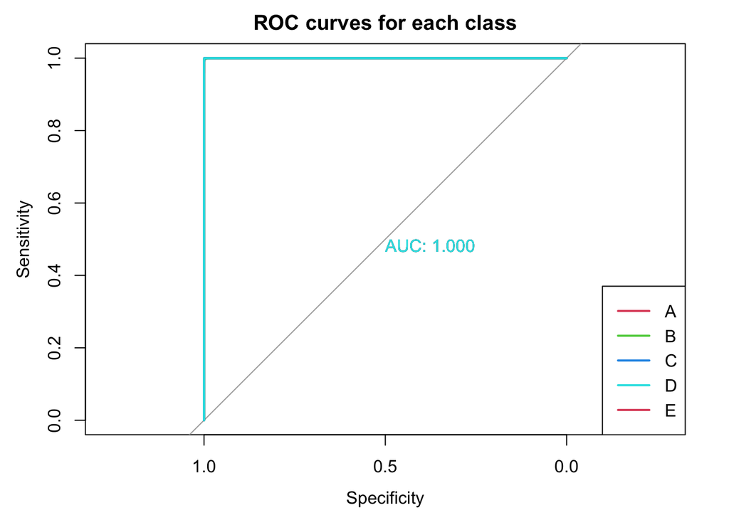

```r
legend("bottomright", legend = levels(actual_classes), lwd = 2, col = 2:length(roc_list))
```

Apply generalized boosted model (GBM) to the train_set

```r
set.seed(2222)
train_control <- trainControl(method = "cv", number = 5) # 5-fold cross validation
# train the decision tree model using 5-fold cross validation
fit_GBM <- train(classe ~.,data = train_set, method = "gbm",
                              trControl = train_control, verbose = FALSE)
# print the model
fit_GBM$finalModel
```

```
## A gradient boosted model with multinomial loss function.
## 150 iterations were performed.
## There were 53 predictors of which 53 had non-zero influence.
```

Predictions of GBM on test_set.

```r
predict_GBM <- predict(fit_GBM, newdata = test_set)
conf_matrix_GBM <- confusionMatrix(predict_GBM, test_set$classe)
conf_matrix_GBM
```

```
## Confusion Matrix and Statistics
##
##           Reference
## Prediction    A    B    C    D    E
##          A 1393    8    0    1    0
##          B    2  928    6    3    4
##          C    0   11  843   14    1
##          D    0    2    6  785    7
##          E    0    0    0    1  889
##
## Overall Statistics
##
##                Accuracy : 0.9865
##                  95% CI : (0.9829, 0.9896)
##     No Information Rate : 0.2845
##     P-Value [Acc > NIR] : < 2.2e-16
##
##                   Kappa : 0.983
##
##  Mcnemar's Test P-Value : NA
##
## Statistics by Class:
##
##                      Class: A Class: B Class: C Class: D Class: E
## Sensitivity            0.9986   0.9779   0.9860   0.9764   0.9867
## Specificity            0.9974   0.9962   0.9936   0.9963   0.9998
## Pos Pred Value         0.9936   0.9841   0.9701   0.9813   0.9989
## Neg Pred Value         0.9994   0.9947   0.9970   0.9954   0.9970
## Prevalence             0.2845   0.1935   0.1743   0.1639   0.1837
## Detection Rate         0.2841   0.1892   0.1719   0.1601   0.1813
## Detection Prevalence   0.2859   0.1923   0.1772   0.1631   0.1815
## Balanced Accuracy      0.9980   0.9870   0.9898   0.9864   0.9932
```

Visualize the confusion matrix as heatmap

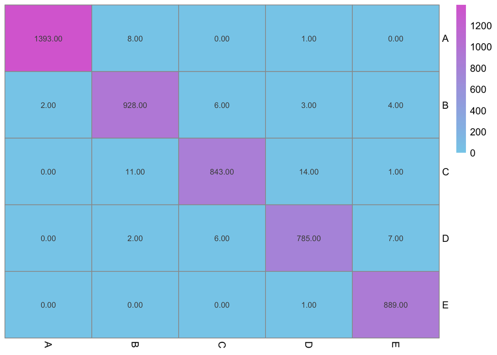

```r
library(pheatmap)
pheatmap(as.matrix(conf_matrix_GBM),
         color = colorRampPalette(c("skyblue","orchid"))(100),
         display_numbers = TRUE,
         cluster_rows = FALSE,
         cluster_cols = FALSE)
```

Compare the efficiency of the 3 models in this analysis.

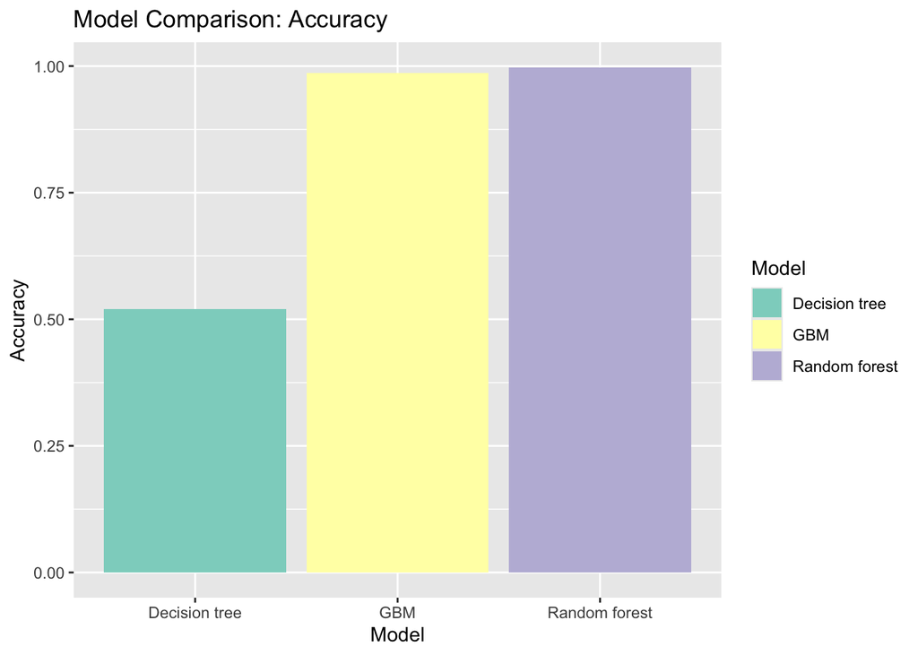

```r
# store different models in a list
models <- list(fit_decision_tree_cv,fit_RF, fit_GBM)
model_names <- c("Decision tree", "Random forest", "GBM")
accuracies <- sapply(models, function(model) confusionMatrix(predict(model, newdata = test_set), test_set$classe)$overall['Accuracy'])

# Create a data frame for plotting
accuracy_df <- data.frame(Model = model_names, Accuracy = accuracies)

# Plot comparison
ggplot(accuracy_df, aes(x = Model, y = Accuracy, fill = Model)) +
  geom_bar(stat = "identity") +
  xlab("Model") +
  ylab("Accuracy") +
  ggtitle("Model Comparison: Accuracy")+
  scale_fill_brewer(name = waiver(), palette = "Set3",direction = 1)
```

Random forest has the highest accuracy.